# Comparing Means

Unit 4 Review

# Introduction

In this activity, you will use everything we’ve covered up to this point including:

- Data manipulation using tidyverse functions
- Hypothesis tests
  - 1-Sample t-test
  - 2-sample dependent t-test
  - 2-sample independent t-test
  - ANOVA
- Confidence Intervals where applicable

We will be using data collected about students in 2 Portuguese schools including their final grade. The goal is to answer research questions using statistical methods to see what factors significantly impact final grades.

## Getting to know a new dataset

In class, we have reinforced a process for approaching a new dataset. The following is a summary of activities that help us conduct good research:

- **Read in the data**
- **Explore the dataset as a whole**:
  - What are the column names? What do they mean? Where can I find information about them?
  - What is the response/dependent variable? Could there be more than one?
  - What are some factors that may impact the response variable? Which are likely the most important?
- **Explore specific columns**
  - Start with the response variable. Are there any outliers? Obtain summary statistics (`favstats()`), visualize the data (`histogram()`, `boxplot()`).
  - Explore the explanatory variables you think are most impact to the response variable. What type of data are they (categorical, quantitative)? For categorical variables, what are all the levels (`unique()`)
- **Formalize statistical hypotheses**. If your factors are categorical, how many groups will you be comparing? Is it a 1-sample t-test, 2-sample t-test, ANOVA?
- **Prepare data for analysis**. You may need to clean the data (eg. `data %>% filter() %>% select()`)
- **Perform the appropriate analysis** (`t.test()`, `aov()`)

All these activities are important, but we may spend more or less time on any one of them depending on the state of the data.

## Load the Libraries and Data

# Review the data

Take some time to familiarize yourself with the data. Check the [website](https://www.kaggle.com/datasets/whenamancodes/student-performance) to see what the columns are.

What is the response variable?

Create a histogram of the response variable.

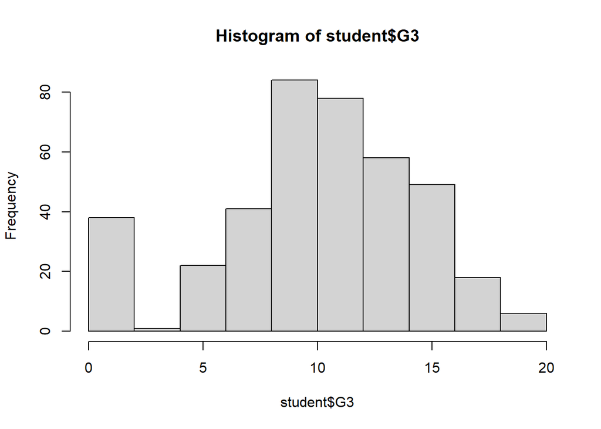

```r
hist(student$G3)
```

What do you notice about the shape of the distribution?

What anomalies, if any, do you notice?

Calculate summary statistics for the response variable.

```r
favstats(student$G3)
```

```
 min Q1 median Q3 max     mean       sd   n missing
   0  8     11 14  20 10.41519 4.581443 395       0
```

**Question**: What is the minimum?  
**Answer**: 0

**Question**: What is the maximum?  
**Answer**: 20

**Question**: How many students participated in the survey?  
**Answer**: 395

**Question**: Rank order the top 5 explanatory variables you think most influence the response and identify each as a categorical or quantitative variable:

1. wants to take higher education (binary: yes or no) (categorical)
2. studytime (quantitative)
3. absences (quantitative)
4. internet (categorical)
5. failures (quantitative)

**NOTE**: Some of the above variables may be quantitative, which is great! Next unit will cover how to analyze those relationships. This assignment, however, focuses on comparing differences between groups and only considers categorical explanatory variables variables.

# Preparing data for analysis

## Categories Labeled as Numbers

Sometimes even correct data can have issues that must be addressed. For example, categories are often labeled as numbers. Software can’t guess when numbers are supposed to be categories, so we have to tell R when a number should be treated as a category.

To force a variable to be a category, we use the `factor()` function in R. We can change the variable type in the data itself or change it in the analysis. We demonstrate both methods below.

### Changing a Column Type in a dataset

Father’s education, `Fedu`, shows up as a number in R. The website suggests that the numbers represent categories (0 = none, 1 = primary education (4th grade), 2 = 5th to 9th grade, 3 = secondary education or 4 = higher education).

To change the data type in the data itself, we can use a mutate statement in the following manner:

```r
# Create a new dataset called fedu_data that begins with the clean data and adds a column that we called Fedu_factor, which is the factorized column, Fedu:

new_data <- student %>%
  mutate(Fedu_factor = factor(Fedu))

# Check the column names of the new dataset.  Notice the new column
names(new_data)

# glimpse() shows us data types.  Notice after Fedu_factor, the <fct>, which shows us that this is in fact, a factor variable type.  <dbl> stands for "double" and is a numeric variable type

glimpse(new_data)
```

[output not shown]

### Changing the Variable Type “on the fly”

You may not want to bother changing all the variable types for each potential analysis. Fortunately, you can create a factor “on the fly” within the analysis function itself.

Because there are more than 2 levels of Father’s Education, I will demonstrate how this is done in an ANOVA:

```r
# Force Fedu to be treated like a category in ANOVA:
fedu_anova <- aov(student$G3 ~ factor(student$Fedu))

summary(fedu_anova)
```

```
                      Df Sum Sq Mean Sq F value Pr(>F)
factor(student$Fedu)   4    238   59.53   2.891 0.0222 *
Residuals            390   8032   20.59
---
Signif. codes:  0 '***' 0.001 '**' 0.01 '*' 0.05 '.' 0.1 ' ' 1
```

This works with most analysis functions including `t.test()` and `aov()`.

**NOTE**: You only have to do this for variables in a dataset that are categories labeled as numbers. If the categories are text, `t.test()` and `aov()` automatically recognizes the variable as categorical. However, it does no harm to put a column with text into a `factor()` statement.

## Cleaning the Data

While exploring the data, you may have noticed a few students ended up with a final grade of zero. While it may be interesting to explore what factors lead to an incomplete grade, we want to make conclusions about students who completed the course.

Create a clean dataset called, `clean`, that excludes zeros for G3. This will be used for the following analyses.

```r
clean <- student %>%
  filter(!G3 %in% 0)
```

# Perform the Appropriate Analysis

## Comparing Schools

Suppose the Gabriel Pereira school (GP) has more stringent admissions requirements. We suspect this would lead to higher grades, on average.

Create a side-by-side boxplot of the final grades for each school. Change the y-axis label to read “Final Grade out of 20”, the x-axis label to read “School”, and add a title.

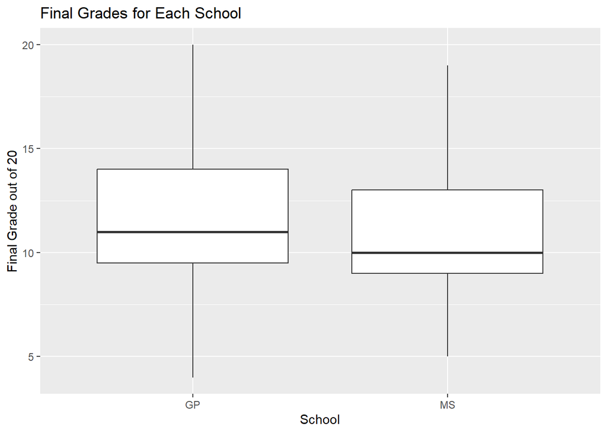

```r
ggplot(clean, mapping = aes(x = school, y = G3)) +
geom_boxplot() +
labs(x = "School",
     y = "Final Grade out of 20",
     title = "Final Grades for Each School")
```

**Question**: What do you notice?  
**Answer**: The median final grade of GP is higher.

Create a table of summary statistics of final grade for each school:

```r
favstats(clean$G3 ~ clean$school)
```

```
  clean$school min  Q1 median Q3 max     mean       sd   n missing
1           GP   4 9.5     11 14  20 11.62222 3.241866 315       0
2           MS   5 9.0     10 13  19 10.78571 3.056666  42       0
```

### Hypothesis Test

Create a qqPlot to look at the normality of both groups:

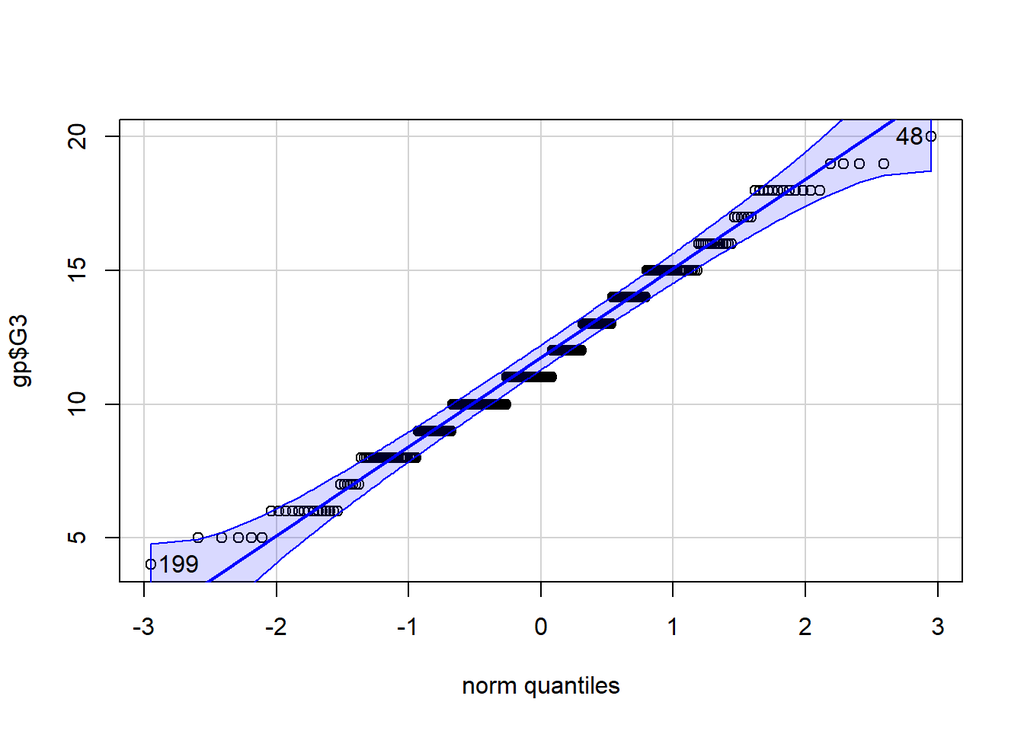

```
[1]  48 199
```

```r
gp <- clean %>% filter(clean$school %in% "GP")
ms <- clean %>% filter(clean$school %in% "MS")
qqPlot(gp$G3)
```

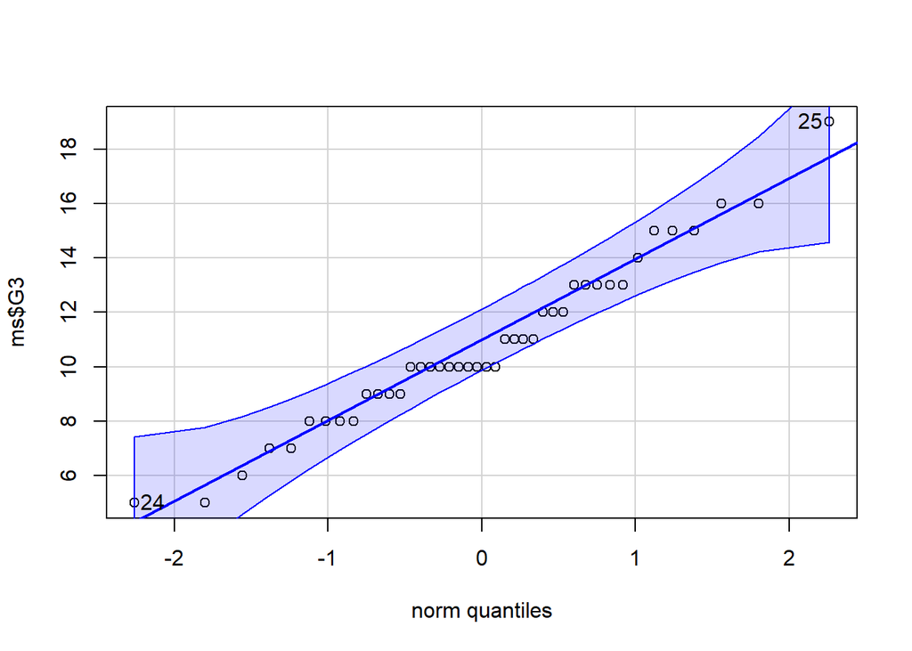

```
[1] 25 24
```

```r
qqPlot(ms$G3)
```

```r
sd1 <- favstats(gp$G3)$sd
sd2 <- favstats(ms$G3)$sd

sd1 / sd2
```

```
[1] 1.060589
```

**Question**: Do the grades look normally distributed for both groups? If not, should we be concerned?  
**Answer**: Yes, both groups look normally distributed and we should’t be concerned about skewed data. Also because the standard deviation ratio is less than 2.

**Question**: Can we trust the P-value?  
**Answer**: Because the grades look normally distributed for both groups, the P-value can be trusted

State your null and alternative hypotheses and significance level.

**NOTE**: Recall that R uses alphabetical order to determine which group is the reference group. It is useful to put this group on the left side of the null hypothesis and set your alternative hypothesis accordingly.

$$GPG3=MSG3$$

$$GPG3>MSG3$$

```r
t.test(gp$G3, ms$G3, alternative = "greater", var.equal = TRUE)
```

```
    Two Sample t-test

data:  gp$G3 and ms$G3
t = 1.581, df = 355, p-value = 0.05739
alternative hypothesis: true difference in means is greater than 0
95 percent confidence interval:
 -0.03608112         Inf
sample estimates:
mean of x mean of y
 11.62222  10.78571
```

**Question**: What is the P-value?  
**Answer**: 0.05739

**Question**: What is your conclusion in context of the research question?  
**Answer**: The probability that the mean G3 score of GP and MS to be equal is 0.05739, at a significance of 5%, there isn’t enough evidence to conclude that stringent admissions requirements would lead to higher grades on average.

### Confidence Interval

Create a $(1-\alpha)$% confidence interval and explain it in context of the research question.

```r
t.test(gp$G3, ms$G3, conf.level = 0.95)
```

```
    Welch Two Sample t-test

data:  gp$G3 and ms$G3
t = 1.6539, df = 54.062, p-value = 0.1039
alternative hypothesis: true difference in means is not equal to 0
95 percent confidence interval:
 -0.1775092  1.8505250
sample estimates:
mean of x mean of y
 11.62222  10.78571
```

## Comparing Second Period Grade with Final Grade

We suspect there is a difference between the second period and the final grade, though we do not know if they go up or down. Carry out a hypothesis test to evaluate this suspicion.

### Hypothesis Test

Choose how you will define the difference between final grade and second period grade, and create a new object called `diff`:

```r
diff <- clean$G3 - clean$G2
favstats(diff)
```

```
 min Q1 median Q3 max      mean        sd   n missing
  -2  0      0  1   3 0.1652661 0.8400931 357       0
```

**Question**: What does a negative number mean?  
**Answer**: It would mean that final grades are lower on average than second period grades.

Create a `qqPlot()` of `diff` and check for normality:

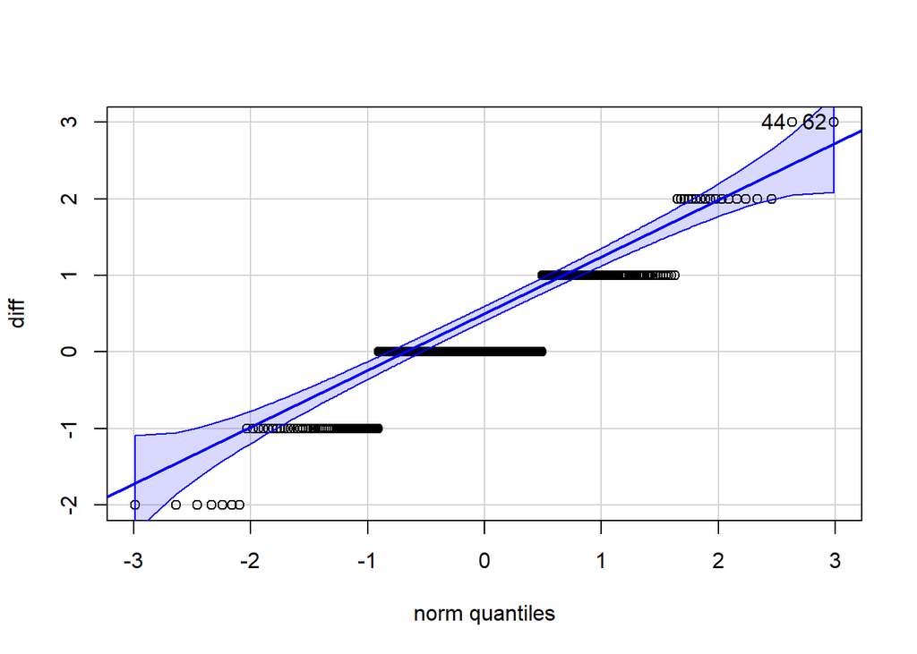

```
[1] 44 62
```

```r
qqPlot(diff)
```

**Question**: Do the grade differences look normally distributed? If not, should we be concerned?  
**Answer**: No, it doesn’t look normally distributed and would imply that we should be concerned about skewed values.

**Question**: Can we trust the P-value?  
**Answer**: Yes because we have a sample size above 30 and standard deviation ratios is less than 2

State your null and alternative hypothesis and choose a significance level:

$$H_d=0$$

$$H_a!=0$$

Perform the appropriate analysis.

```r
t.test(diff, alternative = "two.sided")
```

```
    One Sample t-test

data:  diff
t = 3.717, df = 356, p-value = 0.0002341
alternative hypothesis: true mean is not equal to 0
95 percent confidence interval:
 0.07782404 0.25270817
sample estimates:
mean of x
0.1652661
```

**Question**: What is the P-value?  
**Answer**: 0.0002341

**Question**: What conclusion do you make in context of this research question?  
**Answer**: The the probality of grades between final grades and second period grades are different is 0.02341%, which is significant at a 5% alpha to have enough evidence to reject the null and belive there is a difference in grades.

### Confidence Interval

Create a $(1-\alpha)$% confidence interval for the differences and explain it in context of the research question.

```r
t.test(diff, conf.level = 0.95)
```

```
    One Sample t-test

data:  diff
t = 3.717, df = 356, p-value = 0.0002341
alternative hypothesis: true mean is not equal to 0
95 percent confidence interval:
 0.07782404 0.25270817
sample estimates:
mean of x
0.1652661
```

**Explanation**: I am 95% confident the mean difference is between 0.07782404 0.25270817, which doesn’t include 0, impliying there is significant difference between final and second period grades.

## Absenteeism in Portugal

In 2021, Portugal [reported](https://ec.europa.eu/eurostat/statistics-explained/index.php?title=Secondary_education_statistics#Out-of-school_rates) having 0% absenteeism for 15-year-olds. We suspect that the actual absenteeism is higher than the reported value (zero).

Create a dataset that includes only students who are 15 years old.

```r
fifth <- clean %>% filter(clean$age == 15)
```

### Hypothesis Test

Create a `qqPlot()` for absences.

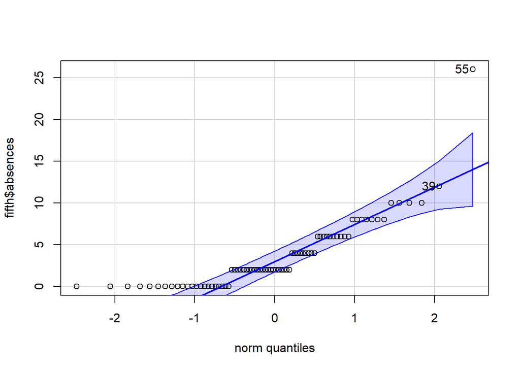

```
[1] 55 39
```

```r
qqPlot(fifth$absences)
```

**Question**: Can we trust the P-value?  
**Answer**: Yes because the data is approximately distributed.

State your null and alternative hypotheses and choose a significance level:

$$H_o=0$$

$$\alpha = 0.05$$

Perform the appropriate analysis.

```r
t.test(fifth$absences, mu = 0, alternative = "greater")
```

```
    One Sample t-test

data:  fifth$absences
t = 7.6314, df = 75, p-value = 2.991e-11
alternative hypothesis: true mean is greater than 0
95 percent confidence interval:
 2.818474      Inf
sample estimates:
mean of x
 3.605263
```

**Question**: What is the P-value?  
**Answer**: 2.991e-11

**Question**: What conclusion do you make in context of this research question?  
**Answer**: the probality of absenteeism being 0 is 2.991e-11, which is significant at 5% alpha, impliying the absenteeism is higher, thus we reject the null hypothesis and have enough evidence to believe absenteeism is higher.

### Confidence Interval

Create a $(1-\alpha)$% confidence interval for average absences and interpret it in context of the problem.

```r
t.test(fifth$absences, conf.level = 0.95)
```

```
    One Sample t-test

data:  fifth$absences
t = 7.6314, df = 75, p-value = 5.983e-11
alternative hypothesis: true mean is not equal to 0
95 percent confidence interval:
 2.664144 4.546382
sample estimates:
mean of x
 3.605263
```

**Explanation**: I am 95% absences are between 2.664144 4.546382, which 0 is not included, impliying that the absences are greater than 0.

## The Impact of Mother’s Education Level

The level of education of the mother in the home is thought to have a significant impact on student success.

Create a side-by-side boxplot of final grades for each level of mother’s education.

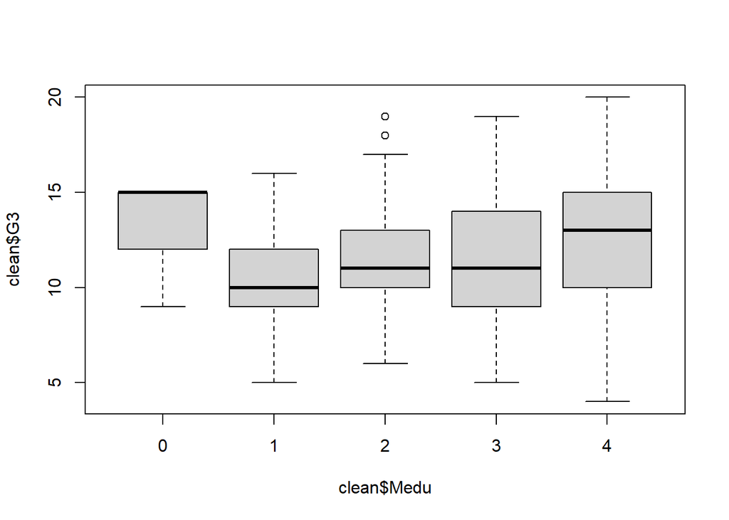

```r
boxplot(clean$G3 ~ clean$Medu)
```

Create a table of summary statistics of final grades for each level of mother’s education.

```r
favstats(clean$G3 ~ clean$Medu)
```

```
  clean$Medu min Q1 median    Q3 max     mean       sd   n missing
1          0   9 12     15 15.00  15 13.00000 3.464102   3       0
2          1   5  9     10 12.00  16 10.24000 2.495383  50       0
3          2   6 10     11 13.00  19 11.25843 2.736654  89       0
4          3   5  9     11 13.75  19 11.33333 3.424958  90       0
5          4   4 10     13 15.00  20 12.32800 3.475202 125       0
```

**Question**: How many respondents have a mother with no formal education (level 0)?  
**Answer**: 3

Create a new dataset, `clean_medu`, that does not include mother’s education level 0.

```r
clean_medu <- clean %>% filter(!clean$Medu == 0)
```

Create another boxplot with the new dataset that excludes level 0.

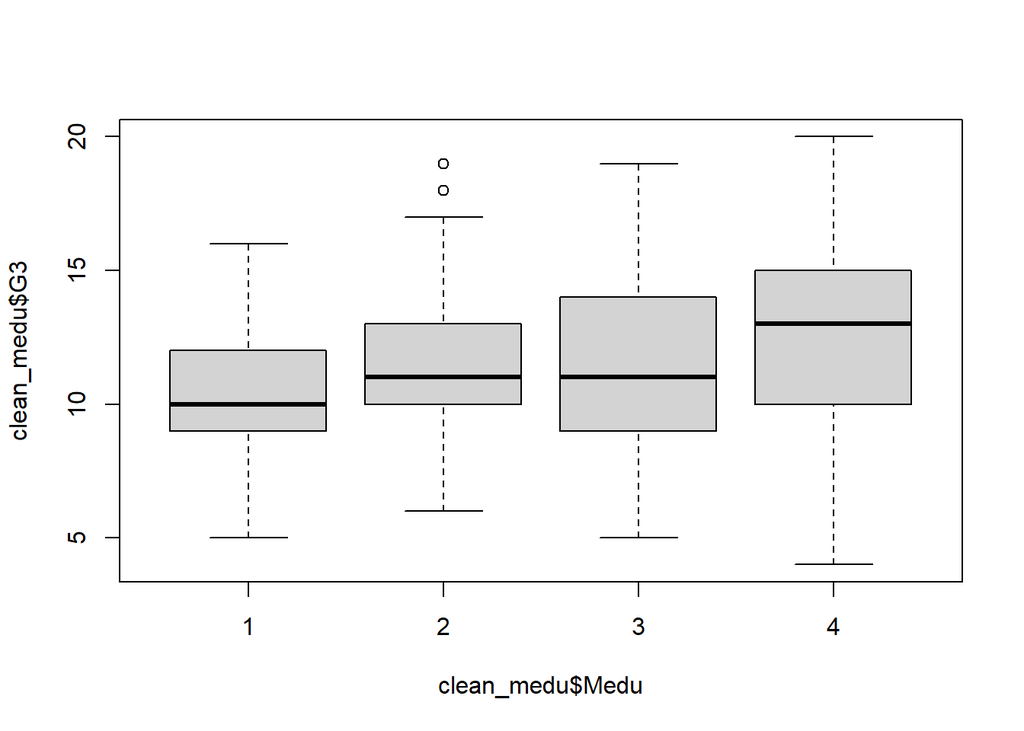

```r
boxplot(clean_medu$G3 ~ clean_medu$Medu)
```

Create a summary table of final grades for each level of a mother’s education with the new dataset.

```r
favstats(clean_medu$G3 ~ clean_medu$Medu)
```

```
  clean_medu$Medu min Q1 median    Q3 max     mean       sd   n missing
1               1   5  9     10 12.00  16 10.24000 2.495383  50       0
2               2   6 10     11 13.00  19 11.25843 2.736654  89       0
3               3   5  9     11 13.75  19 11.33333 3.424958  90       0
4               4   4 10     13 15.00  20 12.32800 3.475202 125       0
```

**Question**: What is the maximum standard deviation?  
**Answer**: 3.475202

**Question**: What is the minimum standard deviation?  
**Answer**: 2.495383

**Question**: Verify that the maximum is less than twice as large as the minimum to check the “equality of standard deviations”.  
**Answer**: 1.392653, Yes is less

```r
3.475202 /2.495383
```

```
[1] 1.392653
```

### Hypothesis Test

State your null and alternative hypotheses and pick alpha:

$$H_o: M_k = 0$$

$$H_a: M_K !=0$$

Perform the appropriate statistical test.

```r
out <- aov(clean_medu$G3 ~ clean_medu$Medu)
summary(out)
```

```
                 Df Sum Sq Mean Sq F value  Pr(>F)
clean_medu$Medu   1    157   157.5   15.74 8.8e-05 ***
Residuals       352   3521    10.0
---
Signif. codes:  0 '***' 0.001 '**' 0.01 '*' 0.05 '.' 0.1 ' ' 1
```

**Question**: What is the test statistic?  
**Answer**: 15.74

**Question**: What is the P-value?  
**Answer**: 8.8e-05

Check the normality of the residuals.

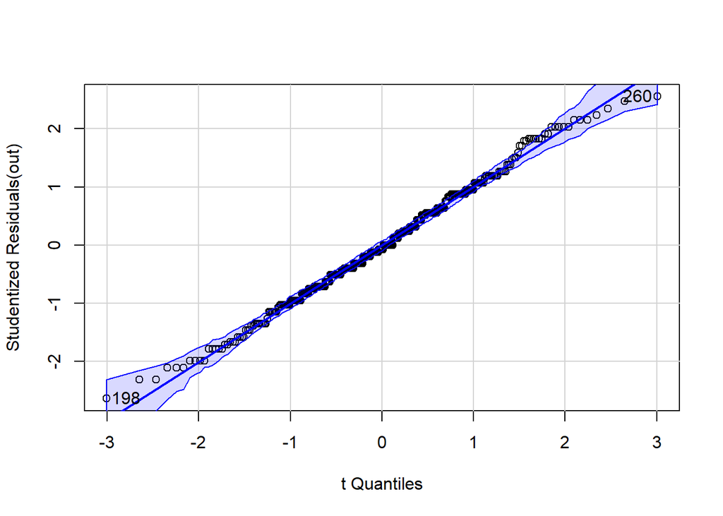

```
[1] 198 260
```

```r
qqPlot(out)
```

**Question**: Do the residuals appear roughly normally distributed?  
**Answer**: Yes, they are all within normality

**Question**: Can we trust the P-value.  
**Answer**: Yes because the aov is normally distributed and the standard deviation ration is less than 2.

State your conclusion.

## Choose your own adventure

Pick another variable that was not analyzed above.

Create a side-by-side boxplot. Be sure to properly label the graph and add sufficient information so readers can know what they are looking at without having to search through the report or code.

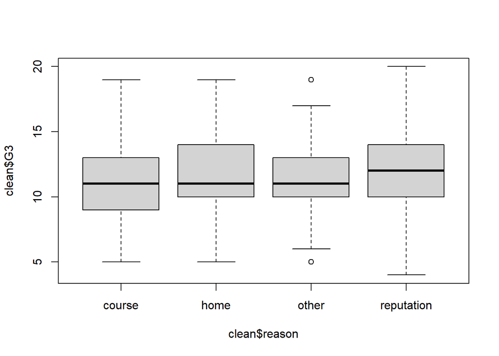

```r
boxplot(clean$G3 ~clean$reason)
```

Perform the appropriate analysis. Be sure to include a concise conclusion in the context of the research question, including a hypothesis test (and confidence interval if applicable.)

```r
favstats(clean$G3 ~clean$reason)
```

```
  clean$reason min Q1 median Q3 max     mean       sd   n missing
1       course   5  9     11 13  19 11.30159 3.247817 126       0
2         home   5 10     11 14  19 11.52577 3.079139  97       0
3        other   5 10     11 13  19 11.48571 3.284289  35       0
4   reputation   4 10     12 14  20 11.81818 3.348358  99       0
```

```r
3.247817 / 3.079139
```

```
[1] 1.054781
```

[figure not shown]

[output not shown]

```r
qqPlot(out)
```

```r
out <- aov(clean$G3 ~clean$reason)
summary(out)
```

```
              Df Sum Sq Mean Sq F value Pr(>F)
clean$reason   3     15   4.951   0.473  0.701
Residuals    353   3694  10.465
```

$$H_o: M_k = 0$$

$$H_a: M_K !=0$$

$$\alpha = 0.05$$

```r
summary(out)
```

```
              Df Sum Sq Mean Sq F value Pr(>F)
clean$reason   3     15   4.951   0.473  0.701
Residuals    353   3694  10.465
```

State your conclusion.